# Projet R - Analyse des données

7 janvier 2020

### Rappel de l’énoncé

Le but de ce projet est d’étudier le lien entre des conditions météorologiques et les retards au départ et à l’arrivée des avions en partance de 3 aéroports de New York.

1. Chargez ces tables dans votre environnement.

```r
library(dplyr)
# pour charger des tables en mémoire, c'est comme pour les fonctions!
# ou on charge le package avec library(package) puis on peut appeler directement
# les tables par leurs noms (et les assigner à un objet du même nom ou d'un autre nom),
# ou on charge chaque table spécifiquement avec nompackage::nombase
flights <- nycflights13::flights
weather <-nycflights13:: weather
planes <- nycflights13::planes
airports <- nycflights13::airports
airlines <- nycflights13::airlines
```

### Premiers traitements

1. Parcourez la base `flights` en affichant les noms et les types des variables présentes. Vous pouvez aussi accéder à un dictionnaire des variables en tapant `?nycflights13::flights` dans votre console.

*Correction* : On affiche le nom avec `names()` et on peut avoir un résumé des colonnes et de leur type avec `str()` :

```r
names(flights)
```

```
##  [1] "year"           "month"          "day"            "dep_time"
##  [5] "sched_dep_time" "dep_delay"      "arr_time"       "sched_arr_time"
##  [9] "arr_delay"      "carrier"        "flight"         "tailnum"
## [13] "origin"         "dest"           "air_time"       "distance"
## [17] "hour"           "minute"         "time_hour"
```

```r
str(flights)
```

```
## Classes 'tbl_df', 'tbl' and 'data.frame':    336776 obs. of  19 variables:
##  $ year          : int  2013 2013 2013 2013 2013 2013 2013 2013 2013 2013 ...
##  $ month         : int  1 1 1 1 1 1 1 1 1 1 ...
##  $ day           : int  1 1 1 1 1 1 1 1 1 1 ...
##  $ dep_time      : int  517 533 542 544 554 554 555 557 557 558 ...
##  $ sched_dep_time: int  515 529 540 545 600 558 600 600 600 600 ...
##  $ dep_delay     : num  2 4 2 -1 -6 -4 -5 -3 -3 -2 ...
##  $ arr_time      : int  830 850 923 1004 812 740 913 709 838 753 ...
##  $ sched_arr_time: int  819 830 850 1022 837 728 854 723 846 745 ...
##  $ arr_delay     : num  11 20 33 -18 -25 12 19 -14 -8 8 ...
##  $ carrier       : chr  "UA" "UA" "AA" "B6" ...
##  $ flight        : int  1545 1714 1141 725 461 1696 507 5708 79 301 ...
##  $ tailnum       : chr  "N14228" "N24211" "N619AA" "N804JB" ...
##  $ origin        : chr  "EWR" "LGA" "JFK" "JFK" ...
##  $ dest          : chr  "IAH" "IAH" "MIA" "BQN" ...
##  $ air_time      : num  227 227 160 183 116 150 158 53 140 138 ...
##  $ distance      : num  1400 1416 1089 1576 762 ...
##  $ hour          : num  5 5 5 5 6 5 6 6 6 6 ...
##  $ minute        : num  15 29 40 45 0 58 0 0 0 0 ...
##  $ time_hour     : POSIXct, format: "2013-01-01 05:00:00" "2013-01-01 05:00:00" ...
```

2. On s’intéresse plus spécifiquement à la durée du vol, sa durée, son retard au départ et à l’arrivée. En utilisant la fonction `is.na`, regardez si ces variables ont des valeurs manquantes. Si oui, créez un dataframe où vous les regroupez. À quoi sont dûs ces valeurs manquantes? Comment les traiter (les sortir de la table ou remplacer la valeur manquante par une autre valeur)?

*Correction* : On crée une base `na_flights` regroupant les observations contenant au moins une valeur manquante pour les variables `air_time`, `distance`, `dep_delay` et `arr_delay` :

```r
# On regroupe les valeurs manquantes
na_flights <- flights %>% filter(is.na(air_time) | is.na(distance)| is.na(dep_delay) | is.na(arr_delay))
na_flights
```

| year | month | day | dep_time | sched_dep_time | dep_delay | arr_time | sched_arr_time | arr_delay | carrier | flight | tailnum | origin | dest | air_time | distance | hour | minute | time_hour |
| --- | --- | --- | --- | --- | --- | --- | --- | --- | --- | --- | --- | --- | --- | --- | --- | --- | --- | --- |
| 2013 | 1 | 1 | 1525 | 1530 | -5 | 1934 | 1805 | NA | MQ | 4525 | N719MQ | LGA | XNA | NA | 1147 | 15 | 30 | 2013-01-01 15:00:00 |
| 2013 | 1 | 1 | 1528 | 1459 | 29 | 2002 | 1647 | NA | EV | 3806 | N17108 | EWR | STL | NA | 872 | 14 | 59 | 2013-01-01 14:00:00 |
| 2013 | 1 | 1 | 1740 | 1745 | -5 | 2158 | 2020 | NA | MQ | 4413 | N739MQ | LGA | XNA | NA | 1147 | 17 | 45 | 2013-01-01 17:00:00 |
| 2013 | 1 | 1 | 1807 | 1738 | 29 | 2251 | 2103 | NA | UA | 1228 | N31412 | EWR | SAN | NA | 2425 | 17 | 38 | 2013-01-01 17:00:00 |
| 2013 | 1 | 1 | 1939 | 1840 | 59 | 29 | 2151 | NA | 9E | 3325 | N905XJ | JFK | DFW | NA | 1391 | 18 | 40 | 2013-01-01 18:00:00 |
| 2013 | 1 | 1 | 1952 | 1930 | 22 | 2358 | 2207 | NA | EV | 4333 | N11194 | EWR | TUL | NA | 1215 | 19 | 30 | 2013-01-01 19:00:00 |
| 2013 | 1 | 1 | 2016 | 1930 | 46 | NA | 2220 | NA | EV | 4204 | N14168 | EWR | OKC | NA | 1325 | 19 | 30 | 2013-01-01 19:00:00 |
| 2013 | 1 | 1 | NA | 1630 | NA | NA | 1815 | NA | EV | 4308 | N18120 | EWR | RDU | NA | 416 | 16 | 30 | 2013-01-01 16:00:00 |
| 2013 | 1 | 1 | NA | 1935 | NA | NA | 2240 | NA | AA | 791 | N3EHAA | LGA | DFW | NA | 1389 | 19 | 35 | 2013-01-01 19:00:00 |
| 2013 | 1 | 1 | NA | 1500 | NA | NA | 1825 | NA | AA | 1925 | N3EVAA | LGA | MIA | NA | 1096 | 15 | 0 | 2013-01-01 15:00:00 |

[output cut: 9420 more lines]

3. Sur ces variables, présentez des statistiques (moyenne, écart-type, min, max). Observez-vous des différences de ces statistiques selon l’aéroport d’où est parti l’avion?

*Correction* On peut utiliser `summarise` :

```r
results_flights <- flights %>%
  summarise(arr_delay_moy = mean(arr_delay, na.rm = TRUE),
            dep_delay_moy = mean(dep_delay, na.rm = TRUE),
            distance_moy = mean(distance, na.rm = TRUE),
            air_time_moy = mean(air_time, na.rm = TRUE))
results_flights
```

| arr_delay_moy | dep_delay_moy | distance_moy | air_time_moy |
| --- | --- | --- | --- |
| 6.895377 | 12.63907 | 1039.913 | 150.6865 |

**Pro tip** : Pour appliquer plusieurs fonctions à plusieurs variables sans avoir à écrire autant de lignes, on peut utiliser `summarise_at(vars(mes_variables_separees_par_une_virgule), list(mes_fonctions_separees_par_une_virgule))`, comme ci-dessous :

```r
results_flights <- flights %>%
  summarise_at(vars(arr_delay, dep_delay, distance, air_time),
               list(moy = mean, min = min, max = max, ecart_type = sd), na.rm = TRUE)
results_flights
```

| arr_delay_moy | dep_delay_moy | distance_moy | air_time_moy | arr_delay_min | dep_delay_min | distance_min | air_time_min | arr_delay_max | dep_delay_max | distance_max | air_time_max | arr_delay_ecart_type | dep_delay_ecart_type | distance_ecart_type | air_time_ecart_type |
| --- | --- | --- | --- | --- | --- | --- | --- | --- | --- | --- | --- | --- | --- | --- | --- |
| 6.895377 | 12.63907 | 1039.913 | 150.6865 | -86 | -43 | 17 | 20 | 1272 | 1301 | 4983 | 695 | 44.63329 | 40.21006 | 733.233 | 93.6883 |

Et pour regarder par aéroport d’origine, il suffit d’ajouter un `group_by` avant l’appel à `summarise` :

```r
results_flights_groupby <- flights %>%
  group_by(origin) %>%
  summarise_at(vars(arr_delay, dep_delay, distance, air_time),
               list(moy = mean, min = min, max = max, ecart_type = sd), na.rm = TRUE)
results_flights_groupby
```

| origin | arr_delay_moy | dep_delay_moy | distance_moy | air_time_moy | arr_delay_min | dep_delay_min | distance_min | air_time_min | arr_delay_max | dep_delay_max | distance_max | air_time_max | arr_delay_ecart_type | dep_delay_ecart_type | distance_ecart_type | air_time_ecart_type |
| --- | --- | --- | --- | --- | --- | --- | --- | --- | --- | --- | --- | --- | --- | --- | --- | --- |
| EWR | 9.107055 | 15.10795 | 1056.7428 | 153.3000 | -86 | -25 | 17 | 20 | 1109 | 1126 | 4963 | 695 | 45.52918 | 41.32370 | 730.2239 | 93.34380 |
| JFK | 5.551481 | 12.11216 | 1266.2491 | 178.3490 | -79 | -43 | 94 | 21 | 1272 | 1301 | 4983 | 691 | 44.27745 | 39.03507 | 896.1084 | 113.79430 |
| LGA | 5.783488 | 10.34688 | 779.8357 | 117.8258 | -68 | -33 | 96 | 21 | 915 | 911 | 1620 | 331 | 43.86227 | 39.99302 | 371.6615 | 49.39791 |

On peut montrer leur distribution avec `geom_violin` :

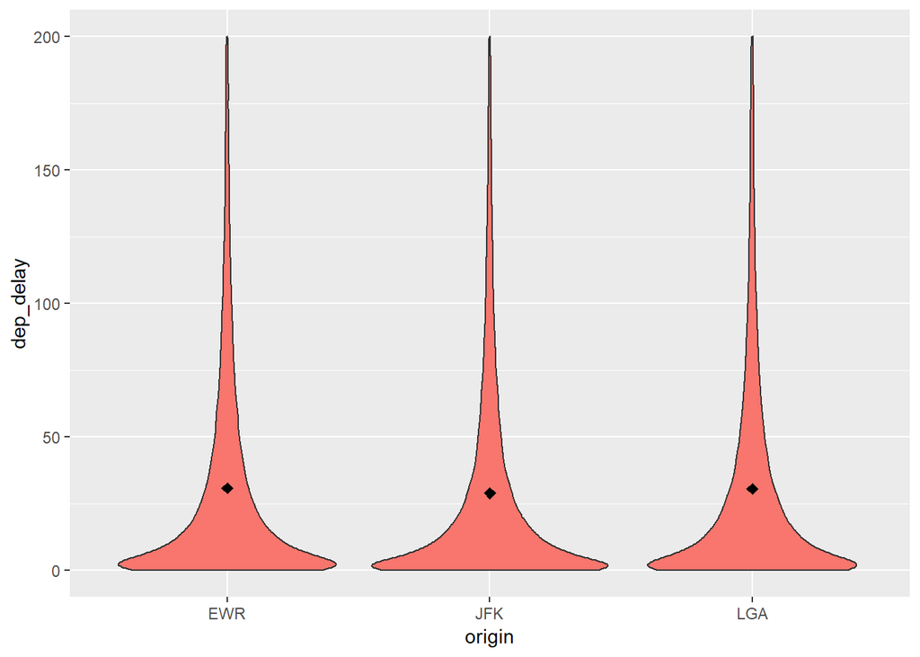

```r
library(ggplot2)
ggplot(flights, aes(x = origin, y = dep_delay, fill = "red")) +
  geom_violin() +
  stat_summary(fun.y=mean, geom="point", shape=23, size=2, fill = "black")+
  ylim(0, 200) +
  theme(legend.position = "none")
```

### Rapprochement avec des données météo

1. De la même manière, parcourez la base `weather` et proposez un traitement des valeurs manquantes.

*Correction* : Exactement pareil que pour `flights` :

```r
names(weather)
```

```
##  [1] "origin"     "year"       "month"      "day"        "hour"
##  [6] "temp"       "dewp"       "humid"      "wind_dir"   "wind_speed"
## [11] "wind_gust"  "precip"     "pressure"   "visib"      "time_hour"
```

```r
str(weather)
```

```
## Classes 'tbl_df', 'tbl' and 'data.frame':    26115 obs. of  15 variables:
##  $ origin    : chr  "EWR" "EWR" "EWR" "EWR" ...
##  $ year      : num  2013 2013 2013 2013 2013 ...
##  $ month     : num  1 1 1 1 1 1 1 1 1 1 ...
##  $ day       : int  1 1 1 1 1 1 1 1 1 1 ...
##  $ hour      : int  1 2 3 4 5 6 7 8 9 10 ...
##  $ temp      : num  39 39 39 39.9 39 ...
##  $ dewp      : num  26.1 27 28 28 28 ...
##  $ humid     : num  59.4 61.6 64.4 62.2 64.4 ...
##  $ wind_dir  : num  270 250 240 250 260 240 240 250 260 260 ...
##  $ wind_speed: num  10.36 8.06 11.51 12.66 12.66 ...
##  $ wind_gust : num  NA NA NA NA NA NA NA NA NA NA ...
##  $ precip    : num  0 0 0 0 0 0 0 0 0 0 ...
##  $ pressure  : num  1012 1012 1012 1012 1012 ...
##  $ visib     : num  10 10 10 10 10 10 10 10 10 10 ...
##  $ time_hour : POSIXct, format: "2013-01-01 01:00:00" "2013-01-01 02:00:00" ...
```

2. Sortez des statistiques sur les variables qui vous semblent pouvoir impacter le retard des avions, sur toute la base puis selon l’aéroport.

*Correction* : Je décide de regarder la moyenne, le min, le max et l’écart type de la visibilité et de la vitesse du vent avec `summarise` de dplyr :

```r
# On choisit d'axer notre analyse sur la visibilité et la vitesse du vent
stats_weather <- weather %>% summarise(visib_moy = mean(visib, na.rm = TRUE),
                                       visib_min = min(visib, na.rm = TRUE),
                                       visib_max = max(visib, na.rm = TRUE),
                                       visib_ecart_type = sd(visib, na.rm = TRUE),
                                       windspeed_moy = mean(wind_speed, na.rm = TRUE),
                                       windspeed_min = min(wind_speed, na.rm = TRUE),
                                       windspeed_max = max(wind_speed, na.rm = TRUE),
                                       windspeed_ecart_type = sd(wind_speed, na.rm = TRUE))
stats_weather
```

| visib_moy | visib_min | visib_max | visib_ecart_type | windspeed_moy | windspeed_min | windspeed_max | windspeed_ecart_type |
| --- | --- | --- | --- | --- | --- | --- | --- |
| 9.255372 | 0 | 10 | 2.055052 | 10.51749 | 0 | 1048.361 | 8.539253 |

On ajoute un `group_by` pour regarder ces stats par aéroport d’origine :

```r
# On choisit d'axer notre analyse sur la visibilité et la vitesse du vent
stats_weather_groupby <- weather %>% group_by(origin) %>%
  summarise(visib_moy = mean(visib, na.rm = TRUE),
            visib_min = min(visib, na.rm = TRUE),
            visib_max = max(visib, na.rm = TRUE),
            visib_ecart_type = sd(visib, na.rm = TRUE),
            windspeed_moy = mean(wind_speed, na.rm = TRUE),
            windspeed_min = min(wind_speed, na.rm = TRUE),
            windspeed_max = max(wind_speed, na.rm = TRUE),
            windspeed_ecart_type = sd(wind_speed, na.rm = TRUE))
stats_weather_groupby
```

| origin | visib_moy | visib_min | visib_max | visib_ecart_type | windspeed_moy | windspeed_min | windspeed_max | windspeed_ecart_type |
| --- | --- | --- | --- | --- | --- | --- | --- | --- |
| EWR | 9.277015 | 0.12 | 10 | 2.007097 | 9.461073 | 0 | 1048.36058 | 12.345755 |
| JFK | 9.177578 | 0.00 | 10 | 2.163345 | 11.468396 | 0 | 42.57886 | 5.902936 |
| LGA | 9.311531 | 0.00 | 10 | 1.988075 | 10.622839 | 0 | 40.27730 | 5.431724 |

3. Quel traitement reste-t-il à faire sur la base de données `flights` pour pouvoir la rapprocher des données météo?

*Correction* : On peut l’aggréger par aéroport et heure de la journée afin d’avoir autant de lignes que d’heures de la journée et d’aéroport :

```r
flights_agreg <- flights %>% group_by(time_hour, origin) %>%
  summarise(dep_delay = mean(dep_delay),
            arr_delay = mean(arr_delay),
            air_time = mean(air_time))
```

Ou la conserver ainsi, et les informations météo se dupliqueront lors du `join` pour les vols partant dans la même heure. Cette dernière option permet de tenir compte des heures où le nombre de départ sont plus importants, alors que la première option revient à lisser le nombre de vols par heure, en mettant un poids égal pour chaque heure de la journée.

4. Fusionnez la table `flights` ainsi transformée et la table `weather` en utilisant la fonction de merge de dplyr qui vous semble la plus appropriée entre `inner_join`, `left_join`, `right_join` et `outer_join`.

*Correction* : On a besoin des informations des 2 tables, on choisit donc `inner_join` :

```r
flights_weather <- flights %>% inner_join(weather, by = c("time_hour", "origin"))

# on sauvegarde cette table dans data/
saveRDS(flights_weather, "data/flights_weather.rds")
```

5. Vérifiez que de nouvelles valeurs manquantes ne sont pas apparues dans cette nouvelle table, si oui traitez-les.

*Correction* : on conserve les valeurs manquantes dans la table mais on les ignorera pour les graphes et les statistiques.

### Analyse

1. En vous appuyant sur la comparaison des statistiques déjà réalisées et sur au moins 4 représentations graphiques bien choisies, proposez une analyse de l’effet des conditions météorologiques sur les retards des avions. Pensez à définir une problématique en amont, que vous êtes libres de choisir : vous n’êtes pas obligés d’utiliser toutes les variables à disposition!

*Une correction possible*

On soupçonne la vitesse du vent de retarder les vols à leur départ. Pour évaluer cette relation, on représente un nuage de points de `dep_delay` en fonction de `wind_speed`. Dans l’instruction `geom_point`, on ajoute un peu d’aléatoire avec `jitter` pour éviter que les points ne se superposent tous. On fixe également des couleurs différentes par aéroport de départ pour voir si on constate des différences :

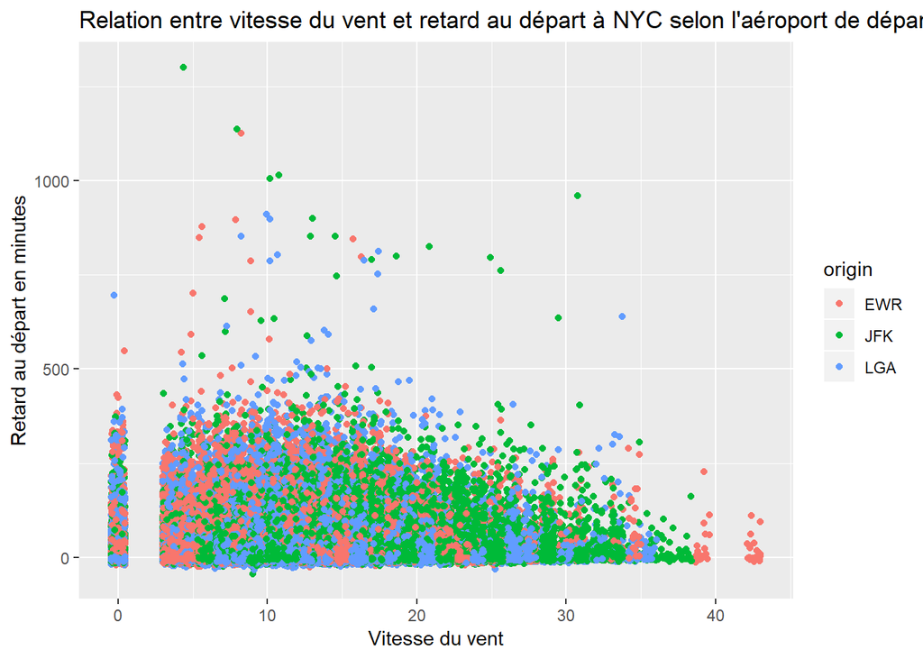

```r
library(ggplot2)

flights_weather %>% ggplot(aes(y = dep_delay, x = wind_speed)) +
  geom_point(aes(color = origin), position = "jitter") +
  labs(title = "Relation entre vitesse du vent et retard au départ à NYC selon l'aéroport de départ",
       y = "Retard au départ en minutes", x = "Vitesse du vent")
```

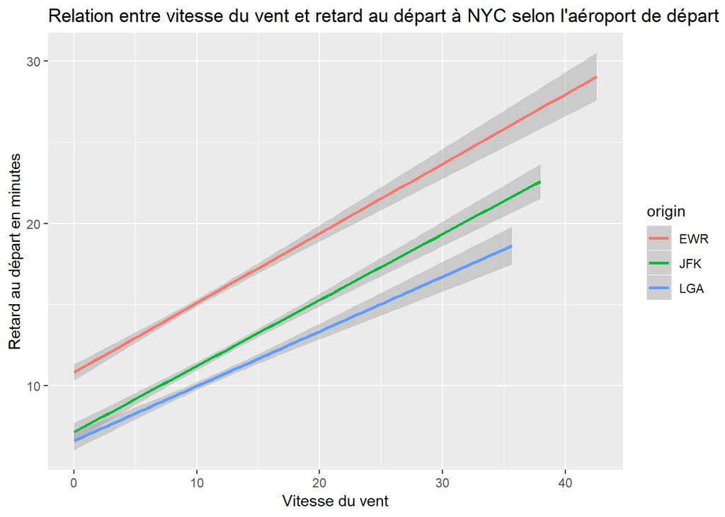

```r
flights_weather %>% ggplot(aes(y = dep_delay, x = wind_speed)) +
  geom_smooth(method = "lm", aes(color = origin)) +
  labs(title = "Relation entre vitesse du vent et retard au départ à NYC selon l'aéroport de départ",
       x = "Vitesse du vent", y = "Retard au départ en minutes")
```

On constate qu’il y a bien une relation positive entre retard au départ et vitesse du vent.

On s’attend a priori à avoir une relation négative entre visibilité et retard au départ. Comme il n’y a pas beaucoup d’occurences de visibilité, on regarde le retard moyen en fonction de la valeur de `visib` (que l’on définit comme un facteur avec `as.factor()` car il a un nombre limité de modalités) et on distingue par aéroport avec le graphe suivant :

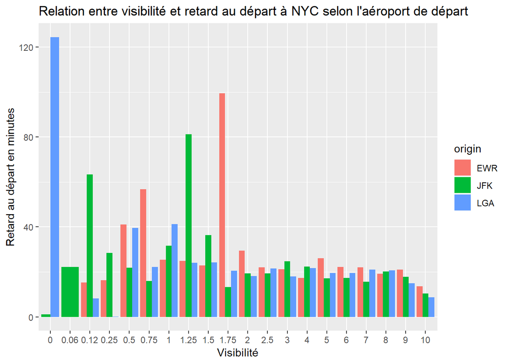

```r
flights_weather %>% group_by(origin, visib) %>%
  summarise(dep_delay = mean(dep_delay, na.rm = TRUE)) %>%
  ggplot(aes(x = as.factor(visib), y = dep_delay)) +
  geom_bar(aes(fill = origin), stat = "identity", position = "dodge") + #position = dodge pour mettre les barres côte à côte
  labs(title = "Relation entre visibilité et retard au départ à NYC selon l'aéroport de départ",
       x = "Visibilité", y = "Retard au départ en minutes")
```

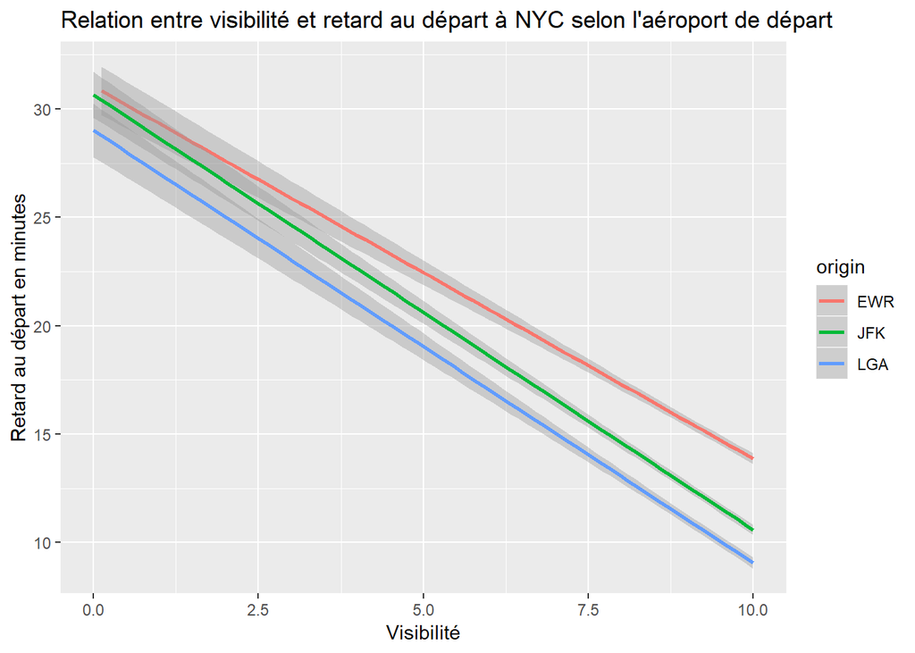

```r
flights_weather %>% ggplot(aes(y = dep_delay, x = visib)) +
  geom_smooth(method = "lm", aes(color = origin)) +
  labs(title = "Relation entre visibilité et retard au départ à NYC selon l'aéroport de départ",
       x = "Visibilité", y = "Retard au départ en minutes")
```

### Quelques sorties inspirées de vos travaux

#### Orientation du vent

L’orientation du vent peut avoir un impact sur le retard provoqué par le vent selon l’orientation de la piste. On peut donc imaginer que cet effet va varier selon l’aéroport de départ. Une visualisation possible serait la suivante :

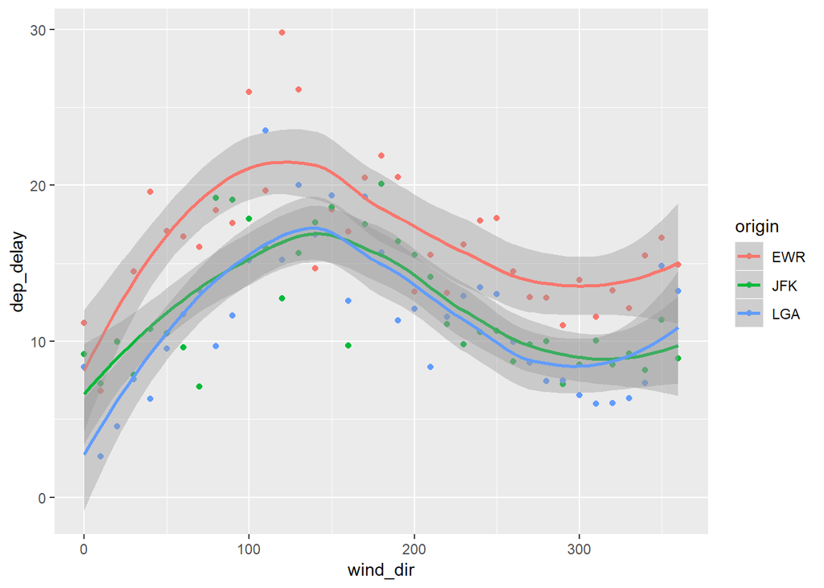

```r
flights_weather %>% group_by(wind_dir, origin) %>%
  summarise(dep_delay = mean(dep_delay, na.rm = TRUE)) %>%
  ungroup() %>%
  ggplot(aes(y = dep_delay, x = wind_dir)) +
  geom_point(aes(color = origin)) +
  geom_smooth(aes(color = origin))
```

#### Valeurs manquantes

On soupçonne les valeurs manquantes d’être dûes à des vols annulés. Ces vols annulés pourraient l’être pour des conditions météo. Regardons par exemple si il y a plus de valeurs manquantes de `dep_delay` proportionnellement au nombre de vols en fonction de la vitesse du vent :

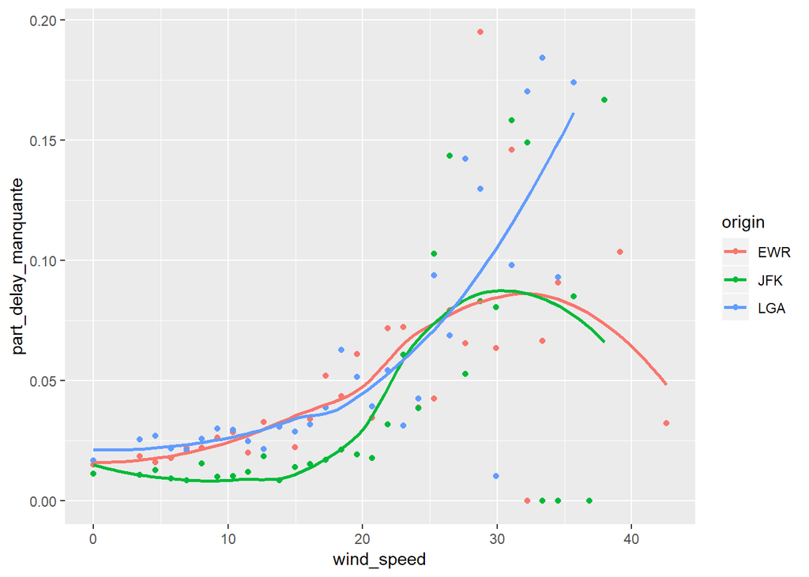

```r
flights_weather %>% mutate(dep_delay_manquante = if_else(is.na(dep_delay), 1, 0)) %>%
  group_by(origin, wind_speed) %>%
  summarise(part_delay_manquante = sum(dep_delay_manquante) / n()) %>%
  ggplot(aes(y = part_delay_manquante, x = wind_speed)) +
  geom_point(aes(color = origin)) +
  geom_smooth(aes(color = origin), se = FALSE)
```

Pareil pour la visibilité :

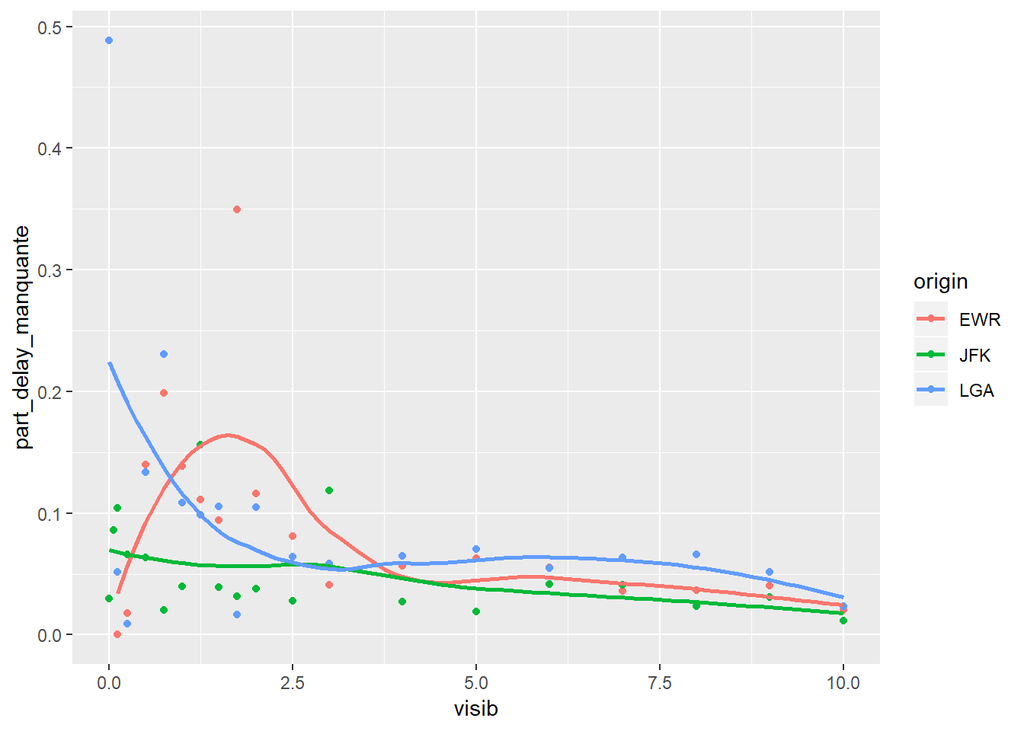

```r
flights_weather %>% mutate(dep_delay_manquante = if_else(is.na(dep_delay), 1, 0)) %>%
  group_by(origin, visib) %>%
  summarise(part_delay_manquante = sum(dep_delay_manquante) / n()) %>%
  ggplot(aes(y = part_delay_manquante, x = visib)) +
  geom_point(aes(color = origin)) +
  geom_smooth(aes(color = origin), se = FALSE)
```

#### Retards en fonction de la saison

On peut aussi regarder si les retards évoluent en fonction de la saison :

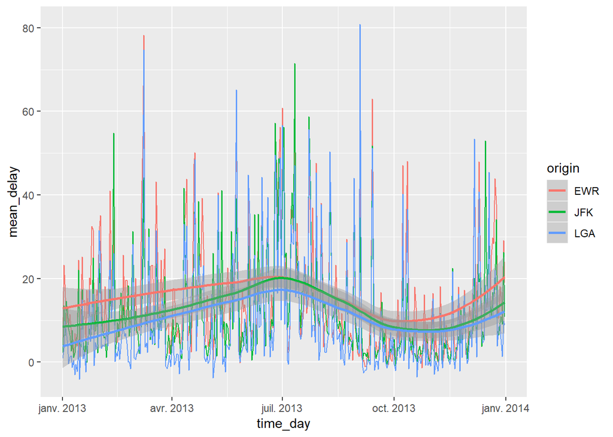

```r
flights_weather %>%
  mutate(time_day = as.POSIXct(round(time_hour, "day"))) %>%
  group_by(time_day, origin) %>%
  summarise(mean_delay = mean(dep_delay, na.rm = TRUE)) %>%
  ungroup() %>%
  ggplot(aes(x = time_day, y = mean_delay)) +
  geom_line(aes(color = origin))+
  geom_smooth(aes(color = origin)) # smooth pour l'ensemble
```